# DataCompPractice

Jerad Acosta

March 6, 2015

### Load Data

```r
data <- read.table("/Users/irJERAD/1DataContest/ExpulsionSuspensionData/2013-14SuspExpData.txt", sep="\t", header = T, fill = T)
# Use fill = T because starting at line 5016 missing values have an asterisk "*"
```

**Variable Names** > names(d) [1] “AggegateLevel” “Cds” “Name” “DisciplineType”  
[5] “Ethnicity” “Weapons” “Drugs” “ViolenceWithInjury”  
[9] “ViolenceWithoutInjury” “OtherNonDefiance” “OtherDefiance” “Total”  
[13] “Year” “DateCreated” “DateUpdated”

### Dimensions (pre Tidy)

Data set has 15 variables and 72310 Observations

```r
dim(data)
```

```
## [1] 72310    15
```

```r
# [1] 72310    15
sum(as.integer(data$Drugs))
```

```
## [1] 604509
```

```r
# [1] 604509
# OR sum(as.integer(data$[[7]]))
```

#### All Sums

**There is Some Overlap**  
bc 324726 + 604509 + 611473 + 2124247 + 598305 + 2107312 = 6370572  
but total is 4950594

**Need to create Tidy data set**

### Creating a Tidy data subset for analysis

#### By School

```r
library(dplyr) # to subset observations and Variables
schoolTotals <- filter(data, AggegateLevel == 'T') # Data.frame of school totals
# 27 observations >> so we must have 27 unique schools
# To Check:
```

```r
schoolTotals == distinct(schoolTotals)
 [1] TRUE
```

```r
# coerse classes to appropriate for visualization and grammar of graphics
for (i in 6:12) {
        # Convert Weapons, Drugs, ViolenceWithInjury, ViolenceWithoutInjury
        # OtherNonDefiance OtherDefiance and Total as integers for graphics
        schoolTotals[[i]] <- as.integer(schoolTotals[[i]])
}
# cast Ethnicity as factor for aesthetic differentiation
schoolTotals$Ethnicity <- as.factor(schoolTotals$Ethnicity)

# create data directory
if(!file.exists("RData")) {
    dir.create("RData")
}
# write new data into data file
write.table(schoolTotals, file = "./RData/schoolTotalSuspExp")
```

### Ideas

- Explore unfair punishment (based on ethnicity) + DisciplineType across different Ethnicity + keep Offense Category constant (Drugs, Weapons, etc) + Use Residency in San Diego School by Race/Ethnicity http://s3.sandiegodata.org.s3.amazonaws.com/share/data_contest_2015/education/sandi.net/Residency%20by%20Ethnicity%201415%20Flat.xlsx

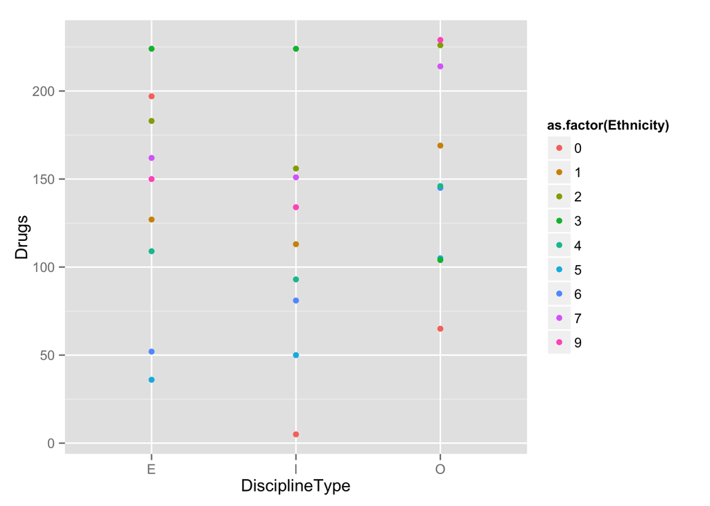

```r
library(ggplot2)
qplot(DisciplineType, Drugs, data = schoolTotals, color = as.factor(Ethnicity))
```

```r
# Ethnicity is an integer, need to cast as factor
```

#### rCharts D3 JavaScript Library

```r
library(devtools)
library(rCharts)
# Create Stacked and grouped interactive Bar Charts
n1 <- nPlot(Weapons ~ DisciplineType, group = "Ethnicity", data = schoolTotals, type = "multiBarChart", cdn = TRUE)
n1$show('inline', include_asset = TRUE)
```

[output not shown]

```r
# Lined Dot
x1 <- xPlot(ViolenceWithoutInjury ~ DisciplineType, group = "Ethnicity", data = schoolTotals, type = "line-dotted", cdn = TRUE)
x1$show('inline', include_assets = TRUE)
```

[output not shown]

```r
# Total Disciplinary Action (Each a different color) Vs Ethnicity
n1 <- nPlot(Total ~ Ethnicity, group = "DisciplineType", data = schoolTotals, type = "multiBarChart", cdn = TRUE)
n1$show('inline', include_assets = TRUE)
```

[output not shown]

0=Not Reported  
1=American Indian or Alaskan Native, not Hispanic  
2=Asian, not Hispanic  
3=Pacific Islander, not Hispanic 4=Filipino, not Hispanic 5=Hispanic or Latino  
6=African American, not Hispanic 7=White, not Hispanic  
9=Two or more races, not Hispanic

Ideally we would like to see students spending as much time in school as possible. Some of the benefits to keeping students in school: * Education + Personal Enrichment and development + Social Skills + Academic Skills * Economic + Allowing Parents to work + Saving money on child care for parents + Investing in Students economic future via education

Thus, due to the importance of keeping students in school we would want to see Expulsion as a last resort for discipline. Using similar logic, we can conclude that In-School Suspensions should be considered a better alternative to Out-Of-School Suspensions whenever possible.

Unfortunately the data does not follow this pattern of thought.

Additionally we can see a great disproportion between disciplinary actions given to students of different ethnicities. Minorities such as American Indian’s are given over 5 times more out of school suspensions than in-school suspensions in total. The minority groups of Pacific Islander and Filipino as well as the Hispanic or Latino groups each have more than one-third of their disciplinary actions resulting in complete expulsion from school.  
**TODO** * Show these groups are also financially disadvantaged and draw a link to the wealth of a group of students and the disciplinary actions they receive. * Check census data to confirm the number of students receiving these disciplinary actions is much greater than the proportion of them enrolled in the schools. + could also check STAR test data for student ethnicity enrollment rates.